[figure not shown]

# **Part 1 - Working with Data**

# **Introduction**

By now theres no need for an introduction to the importance of data and working with data.

Today we will explore the use of Python for data and data analysis.

We will follow the following schedule and by the end you will be exhausted - promise!  
The good news is that I've tried to make these Notebooks as followable as possible.

- **Preamble:** An *Extremely* Quick introduction to Jupyter and Python.
- **Part 1:** Working with Data (The bulk of todays material)
- **Part 2:** Exploratory Data Visualization with Python.
- **Part 3:** A Quick Overview of Working with Big Data

## **Jupyter command line interfacing.**

Sometimes you need to do something outside the normal realm of Jupyter Notebooks.  
One major example we will take advantage of right now, and that's the ability to install packages from Jupyter.  
For instance we can use pip, or conda, but for speed please consider always using pip from Jupyter else jump back out to the command line.  
There's a delimiter to tell Jupyter that you want to invoke command line commands and that's and bang/explanation mark, '*!*'  
Example:  
`!pip install pandas`

If you have not already done so, or are not sure if you have installed the following packages. If you recieved a module not found error then please uncomment the required lines in the cell below the imports cell execute/run that cell.  
If you have ran an install line(s) then make sure you go back and re-execute the imports cell.

```python
import pandas as pd
import numpy as np
import plotly.graph_objects as go
import glob
import os

import pycountry
import requests
from io import BytesIO
from bs4 import BeautifulSoup
from collections import Counter
```

```python
#!pip install pandas
#!pip install numpy
#!pip install bs4
#!pip install plotly
#!pip install pywidgets
#!pip install requests
#!pip install fastparquet
#!pip install pycountry
#!pip install nltk
```

**NOTE:** There will be a couple others we need but I'm intentionally going to wait to 'after' we need them to install them!

We will move on and talk really quickly about Python in general while these are installing.

# **A Lightning Quick Introduction to Important Python Concepts.**

## **Main data structures - Lists, Tuples, and Dictionaries**

Actually lets step back a little bit first and just look at simple variables.

A variable is just a user defined ‘name’ which which references some sort of data. For example:

```
foo = 37   # The true answer to life, the universe, and just everything! At least nature seems to think so!
```

Here we have created a variable named foo and stored the value of 37 into it. It is followed by a comment on what the value represents.

The true power, beauty, and sadly part of its dark side, is EVERYTHING in Python is a non-typed object. Where a type can be defined as as a bunch of text, an integer value, a float value, a long list or matrix of values or well anything you can dream up. In Python, at least until just now, you never worry about defining the type of data you are creating and/or using like you do in most every other language. Python then ‘interpret’ (spelled best guess but almost correctly) the type for you behind the scenes. Hence why Python is know as an interpreted language as compared to a compiled language.  
**NOTE:** In the past few releases and even more so in the future, the concept of type-hinting has been made available to the hardcore coders that seek performance and data type safety. However due to how it works even deeper under the covers (the GIL if you know a bit about Python) even these type-hints are just that ‘hints’ and Python could conceivably interpret something different at run time. It won’t 'most of the time' but it could! We will not be covering type-hints at all today!

Beyond storing a single piece of data into a variable we have specialized data structures, also refered to as containers, to help us out.  
There are many but the vast majority of the time the base containers you will run into and use use are;

- *Lists []:* Lists are what it claims - a list of values.

  ```
        Each one of them is indexed (behind the scenes), starting from zero, the second index is 1, the third 2, etc.
    Lists uses ‘[]’ to enclose the list of data.
    example foo = [‘Zeroth item’, 1, ‘2’, “3rd item”]
    NOTE: All ‘text’ items are enclosed in either single quotes or double quotes. It pretty much makes no difference which (well till you need both at the same time more later!).
    List are ‘mutable’ meaning you can change them at will!
    <b>NOTE:</b> arrays and matrices are specilized lists in numpy, outside of numpy they are indeed lists for arrays and a list of lists for matrices.
  ```

- *Tuples ():* Tuples are just like lists, but you they are ‘immutable’, meaning once defined they can not be changed.

  ```
    Tuples uses ‘()’ to enclose the list (err tuple) of data.
    example months = (‘January’,‘February’,‘March’,‘April’,‘May’,‘June’,‘July’,‘August’,‘September’,‘October’,‘November’,‘December’)
  ```

- *Sets ():* Think of sets just like a Tuple except they can not have multiple occurances of the same element.  
  That and they are unorded and thus have no slicing/indexing available to them. Normally you will not ever have to deal with sets.  
  However there are occasions with Pandas that you will and we will see one of those occasions today.

Lastly theres the all powerful Dictionaries

- *Dictionaries {}:* Dictionaries are similar to what their name suggests - a dictionary of items which includes a name called a ‘key’ and a ‘value’ that the key is associated with. Dictionaries are always composed of these key, value pairs.

  ```
    Dictionaries uses ‘{}’ to enclose the key/value pair. In addition you assign the keys value using a colon ‘:’.
    example colors = {‘Sun’: ‘is Orange’, ‘Grapes’: ‘are purple’, ‘red’: rgb(255, 0, 0}}
    Dictionaries are mutable.
  ```

Heres a quick comparision of 'some' of their key traits:

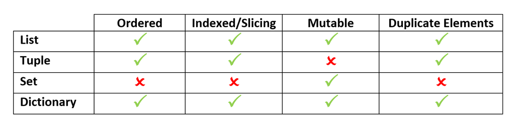

Now the real fun comes in when you understand that you can compose each of these containers into super containers which hold all kinds of other containers. For example;

```
a list of lists
a list of dictionaries
a list of lists of list of list of— (think matrices as both vectors and matrices are actually lists in Python land!)
a list of dictionaries
a dictionary of lists
a dictionary of dictionaries
a dictionary of functions (I personally love using these my apps as part of callback functioanlity!)
```

The list (sorry pun not intended) goes on as far as your imagination will take you!

For data science the two you will use almost all the time are list and dictionaries.  
Well till we dive into Pandas and dataframes which are different yet under the covers are just composed of standard containers!

There are several other main Python features we need to discuss, such as for-loops, functions, magics, and others. But we will explore those when we run into them.